# Ensemble methods

Valentina Zangirolami (valentina.zangirolami@unimib.it)

2025-05-09

```r
#load libraries
library(car)
library(ggplot2)
library(tidymodels)
library(baguette)
library(vip)
library(tidyverse)
```

## *Dataset: ESG DATA*

```r
esg_data <- read.csv("esg_financial_dataset.csv")
head(esg_data)
```

```
##   Industry        Region Revenue ProfitMargin MarketCap GrowthRate ESG_Overall
## 1   Retail Latin America   593.2          4.2     248.4       -1.8        57.7
## 2   Retail Latin America   636.7          5.3     373.9        7.3        57.8
## 3   Retail Latin America   687.0          4.6     460.1        7.9        58.5
## 4   Retail Latin America   734.5          5.0     628.8        6.9        59.2
## 5   Retail          Asia  3106.4          0.8     514.3       -1.9        64.0
## 6   Retail          Asia  3691.6         -0.7    2523.2       18.8        66.0
##   ESG_Environmental ESG_Social ESG_Governance CarbonEmissions WaterUsage
## 1              69.0       27.1           76.9         42536.3    21268.2
## 2              68.3       27.0           78.1         45956.3    22978.2
## 3              68.9       29.9           76.8         49289.1    24644.5
## 4              70.7       29.1           78.0         51805.8    25902.9
## 5              66.7       57.7           67.8        227761.4   113880.7
## 6              66.6       61.6           70.0        271015.1   135507.6
##   EnergyConsumption
## 1           85072.6
## 2           91912.6
## 3           98578.1
## 4          103611.7
## 5          455522.7
## 6          542030.3
```

See the description and data analysis in Multiple Linear regression file.

As before, we should split in training and validation sets

```r
set.seed(123)  # For reproducibility
split <- initial_split(esg_data, prop = 0.8)

train_data <- training(split)
val_data <- testing(split)
```

#### **Ensemble methods: Bagging**

Bagging implementation is already provided by bag_tree() from *baguette* library. We try to implement bagging into a regression tree with the same hyperparameters of our first model in decision_trees.R

```r
# Create recipe
esg_recipe <- recipe(MarketCap ~ ., data = train_data) %>%
  step_dummy(all_nominal_predictors()) %>%
  step_normalize(all_numeric_predictors())

# Create bagging model
bag_spec <- bag_tree(cost_complexity = 0.01, tree_depth = 30, min_n = 20) %>%
  set_engine("rpart", times = 50) %>%
  set_mode("regression")

# Create workflow
bag_wf <- workflow() %>%
  add_recipe(esg_recipe) %>%
  add_model(bag_spec)

# Fit model
bag_fit <- fit(bag_wf, data = train_data)

# Get predictions on training data
train_preds <- predict(bag_fit, new_data = train_data) %>%
  bind_cols(train_data)  # Attach true values
# Get predictions on validation data
val_preds <- predict(bag_fit, new_data = val_data) %>%
  bind_cols(val_data)  # Attach true values

# Compute metrics (e.g., RMSE, R-squared for regression)
metrics <- metric_set(rmse, rsq)
train_metrics <- metrics(train_preds, truth = MarketCap, estimate = .pred)
val_metrics <- metrics(val_preds, truth = MarketCap, estimate = .pred)

round(train_metrics$.estimate, 4)
```

```
## [1] 17444.7732     0.8987
```

```r
round(val_metrics$.estimate,4)
```

```
## [1] 21190.3569     0.8144
```

With bagging, we improved our results. In terms of R-squared, we obtain higher values and a reduced difference between training and validation sets. Also in terms of rmse, the results are better while the distance among these two measures seem to be large.

**Random Forest**

Random Forest combines decision trees and bagging while also sampling randomly features for each tree. The most popular libraries on R are ranger and RandomForest.. In this case, we will use ranger.

Three hyperparameters:

- *mtry*: an integer for the number of predictors that will be randomly sampled at each split when creating the tree models
- *trees*: an integer for the number of trees contained in the ensemble
- *min_n*: an integer for the minimum number of data points in a node that are required for the node to be split further

```r
rf_spec <- rand_forest(mtry = 8, trees = 10, min_n = 8) %>%
  set_engine("ranger", importance = "impurity") %>%
  set_mode("regression")

# Create workflow
rf_wf <- workflow() %>%
  add_recipe(esg_recipe) %>%
  add_model(rf_spec)

# Fit model
rf_fit <- fit(rf_wf, data = train_data)

# Get predictions on training data
train_preds <- predict(rf_fit, new_data = train_data) %>%
  bind_cols(train_data)  # Attach true values
# Get predictions on validation data
val_preds <- predict(rf_fit, new_data = val_data) %>%
  bind_cols(val_data)  # Attach true values

# Compute metrics (e.g., RMSE, R-squared for regression)
metrics <- metric_set(rmse, rsq)
train_metrics <- metrics(train_preds, truth = MarketCap, estimate = .pred)
val_metrics <- metrics(val_preds, truth = MarketCap, estimate = .pred)

round(train_metrics$.estimate, 4)
```

```
## [1] 10519.2870     0.9633
```

```r
round(val_metrics$.estimate,4)
```

```
## [1] 19558.4649     0.8274
```

The results are promising but we still observe overfitting issues. We need to reduce complexity or we can increase the number of trees

```r
rf_spec <- rand_forest(mtry = 8, trees = 100, min_n = 8) %>%
  set_engine("ranger", importance = "impurity") %>%
  set_mode("regression")

# Create workflow
rf_wf <- workflow() %>%
  add_recipe(esg_recipe) %>%
  add_model(rf_spec)

# Fit model
rf_fit <- fit(rf_wf, data = train_data)

# Get predictions on training data
train_preds <- predict(rf_fit, new_data = train_data) %>%
  bind_cols(train_data)  # Attach true values
# Get predictions on validation data
val_preds <- predict(rf_fit, new_data = val_data) %>%
  bind_cols(val_data)  # Attach true values

# Compute metrics (e.g., RMSE, R-squared for regression)
metrics <- metric_set(rmse, rsq)
train_metrics <- metrics(train_preds, truth = MarketCap, estimate = .pred)
val_metrics <- metrics(val_preds, truth = MarketCap, estimate = .pred)

round(train_metrics$.estimate, 4)
```

```
## [1] 9662.0900    0.9705
```

```r
round(val_metrics$.estimate,4)
```

```
## [1] 18889.6331     0.8469
```

We obtained better results on validation set with a slight improvement of overfitting concerns.

Let’s visualize the most important features

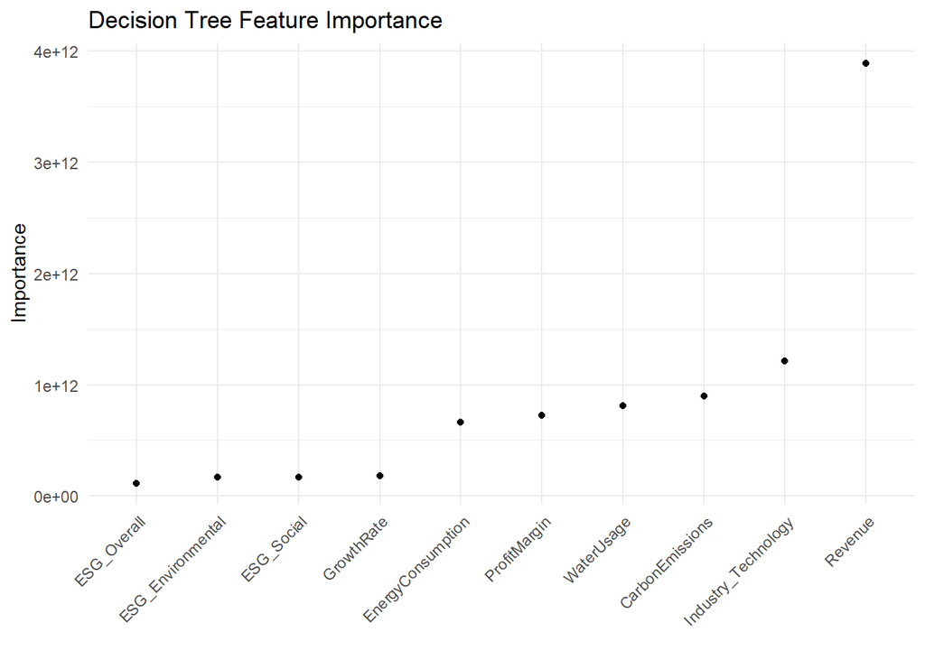

```r
final_model <- extract_fit_engine(rf_fit)

vip(final_model, geom = "point", horizontal = FALSE) +
  ggtitle("Decision Tree Feature Importance") +
  theme_minimal() +
  theme(axis.text.x = element_text(angle = 45, hjust = 1, vjust = 1))
```

#### **Exercise**

Analyze the dataset london_bike_sharing from e-learning and apply appropriate statistical learning while finding good hyperparameters whether it is possible.

```r
london_data <- read.csv("london_bike_sharing.csv")
head(london_data)
```

```
##   daily_cnt t1_max t1_min t1_median t2_max t2_min t2_median weather_code
## 1      9234    4.0    1.0      2.75    3.5   -1.5      0.00            3
## 2     20372   10.0    4.0      9.00    9.0    3.0      7.25            3
## 3     20613   11.0    4.0      8.00   11.0    1.0      5.75            1
## 4     21064   10.0    3.5      9.00    7.0    1.0      5.50            2
## 5     15601   12.0    8.0      9.00   12.0    4.5      6.75            2
## 6     22104   15.5   10.0     13.00   15.5    6.5     13.00            3
##   is_holiday is_weekend season max_hum mean_hum min_hum max_wind_speed
## 1          0          1      3     100 94.27083    87.0           15.0
## 2          0          0      3      93 80.31250    69.0           14.0
## 3          0          0      3      88 78.89583    68.5           27.5
## 4          0          0      3      87 78.10870    62.0           30.5
## 5          0          0      3      88 79.31250    71.0           27.0
## 6          0          0      3      85 74.85417    63.0           44.0
##   mean_wind_speed min_wind_speed
## 1        7.500000              0
## 2        8.854167              5
## 3       16.000000              8
## 4       19.760870              9
## 5       20.479167             13
## 6       32.916667             25
```

Table 1: Description of Variables in the Daily Bike Rentals Dataset

| Variable | Type | Description |
| --- | --- | --- |
| daily_cnt | Numeric | Total daily count of bike rentals. |
| t1_max | Numeric | Maximum real temperature (°C) recorded during the day. |
| t1_min | Numeric | Minimum real temperature (°C) recorded during the day. |
| t1_median | Numeric | Median real temperature (°C) for the day. |
| t2_max | Numeric | Maximum ‘feels like’ temperature (°C) (perceived, considering wind/humidity). |
| t2_min | Numeric | Minimum ‘feels like’ temperature (°C). |
| t2_median | Numeric | Median ‘feels like’ temperature (°C). |
| weather_code | Categorical | Most frequent weather condition of the day (mode). Common codes: 1 = Clear, 2 = Scattered clouds, 3 = Broken clouds, etc. |
| is_holiday | Binary | 1 if the day is a holiday, 0 otherwise. |
| is_weekend | Binary | 1 if the day is a weekend (Saturday/Sunday), 0 otherwise. |
| season | Categorical | Season of the year: 1 = Spring, 2 = Summer, 3 = Fall, 4 = Winter. |
| max_hum | Numeric | Maximum humidity (%) during the day. |
| mean_hum | Numeric | Mean humidity (%) for the day. |
| min_hum | Numeric | Minimum humidity (%) during the day. |
| max_wind_speed | Numeric | Maximum wind speed (km/h or m/s) recorded. |
| mean_wind_speed | Numeric | Mean wind speed for the day. |
| min_wind_speed | Numeric | Minimum wind speed recorded. |